# JLC455_Project3

Melanie Klein

2023-11-30

## Libraries

```r
library(tidyverse)
library(leaflet)
library(sf)
library(tigris)
library(zoo)
library(aTSA)
library(tseries)
library(forecast)
library(data.table)
```

## Forecast 1: Day Shift and Motor Vehicle Theft

For the first forecast, my analysis is based on motor vehicle theft during day shift.

```r
dc.day.motorvehicletheft <- subset(dc.data, dc.data$SHIFT == 'DAY' & dc.data$OFFENSE == 'MOTOR VEHICLE THEFT')
dc.december.day.motorvehicletheft <- subset(dc.day.motorvehicletheft, dc.day.motorvehicletheft$MONTH == '12')
```

#### Bar Graph for December 2023 crimes per day

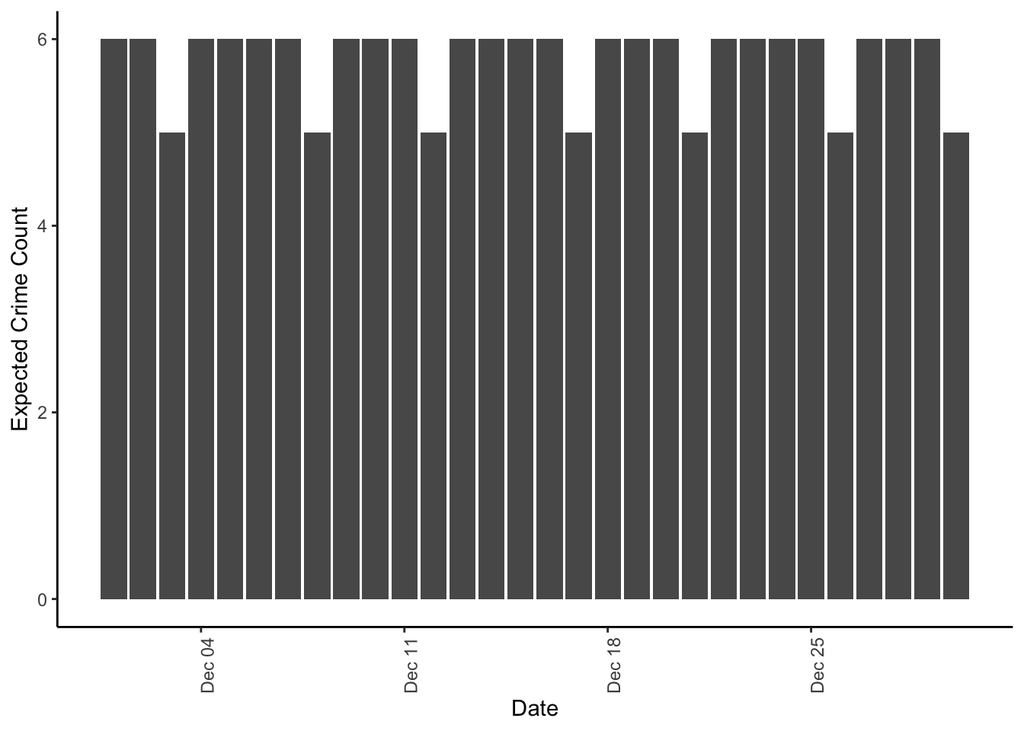

#### Temporal topology for all prior Decembers, by day and hour

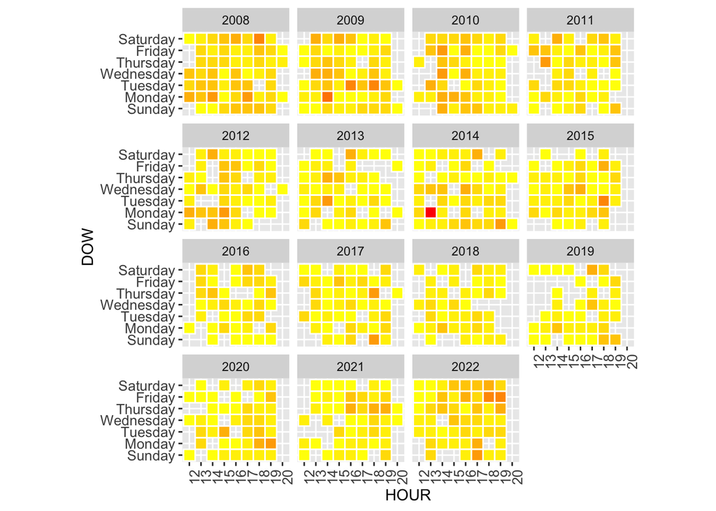

#### Hotspot map for all prior Decembers

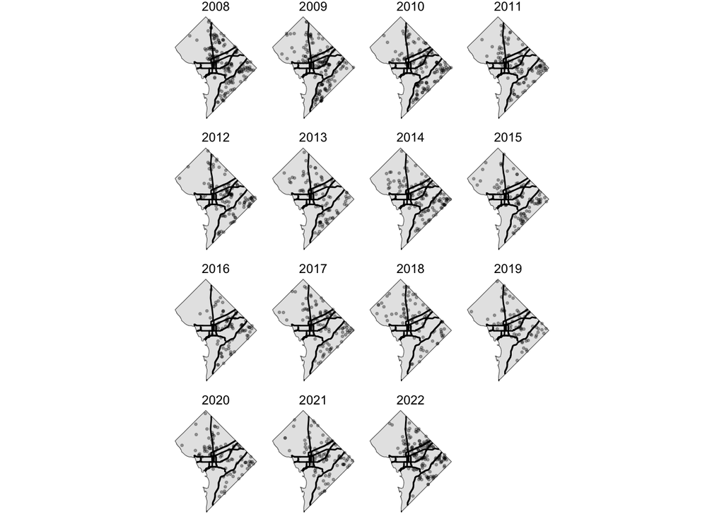

#### Analysis

The daily forecast for expected motor vehicle thefts during day shifts in December is relatively consistent. There is a pattern in which there are 2 to 4 days in a row with 6 expected motor vehicle thefts, followed by a 1 day decrease with 5 expected motor vehicle thefts. Activity has consistently occurred on all days of the week since 2008. Activity is documented from 12pm to 8pm, but occurs less often at 12pm and rarely occurs at 8pm. From 2016 to 2019, there appears to be lower levels of activity because few days had high spikes in activity like previous years had and many hours on various days have no activity despite having activity in previous years. There was a slight increase in activity from 2021 to 2022. Activity occurs relatively consistently over time, primarily in the eastern half of DC, with sparse activity in northwest DC and significant activity in the center of DC. There is a hot spot with a slight decrease in activity over time in southeast DC, and there is a consistent cold spot over time, with almost no activity, in southwest DC.

## Forecast 2: Evening Shift and Burglary

For the second forecast, my analysis is based on burglary during evening shift.

```r
dc.evening.burglary <- subset(dc.data, dc.data$SHIFT == 'EVENING' & dc.data$OFFENSE == 'BURGLARY')
dc.december.evening.burglary <- subset(dc.evening.burglary, dc.evening.burglary$MONTH == '12')
```

#### Bar Graph for December 2023 crimes per evening

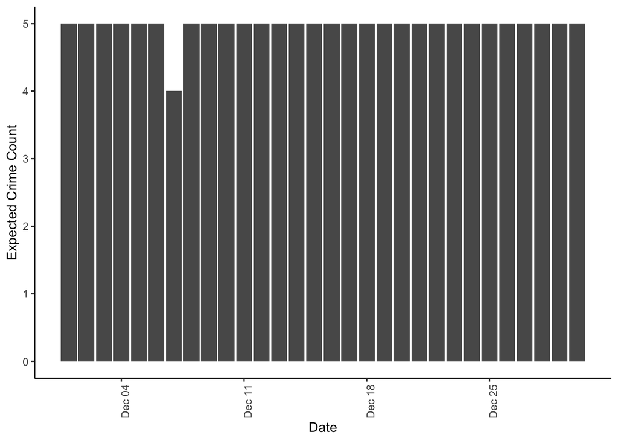

#### Temporal topology for all prior Decembers, by day and hour

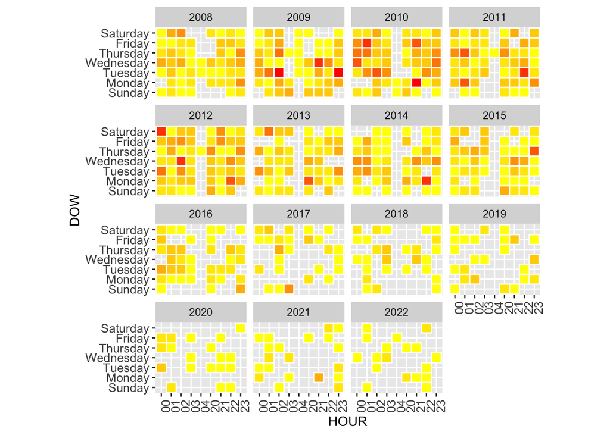

#### Hotspot map for all prior Decembers

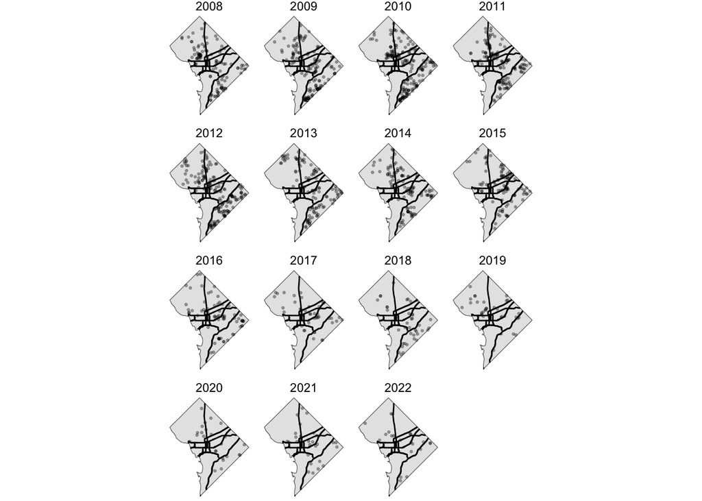

#### Analysis

The daily forecast for expected burglaries during evening shifts in December is consistent at 5 burglaries a day, except for 4 burglaries on December 7th. Activity has occurred on all days of the week since 2008 and is documented from 8pm to 4am, but occurs most infrequently at 4am. There is a significant decrease in activity over time, in which there used to be high levels of activity during the majority of hours stated above every day from 2008 to 2015, but since 2016 there were decreasingly low levels of activity during a handful of hours every day. When there was high activity from 2008 to 2015, there were hot spots in northwest DC and southeast DC, varied activity in northeast DC, and cold spots with no activity in southwest DC. When activity significantly decreased from 2016 to 2022, it was scattered without any distinct hot spots.

## Forecast 3: Midnight Shift and Robbery

For the third forecast, my analysis is based on robbery during midnight shift.

```r
dc.midnight.robbery <- subset(dc.data, dc.data$SHIFT == 'MIDNIGHT' & dc.data$OFFENSE == 'ROBBERY')
dc.december.midnight.robbery <- subset(dc.midnight.robbery, dc.midnight.robbery$MONTH == '12')
```

#### Bar Graph for December 2023 crimes per midnight

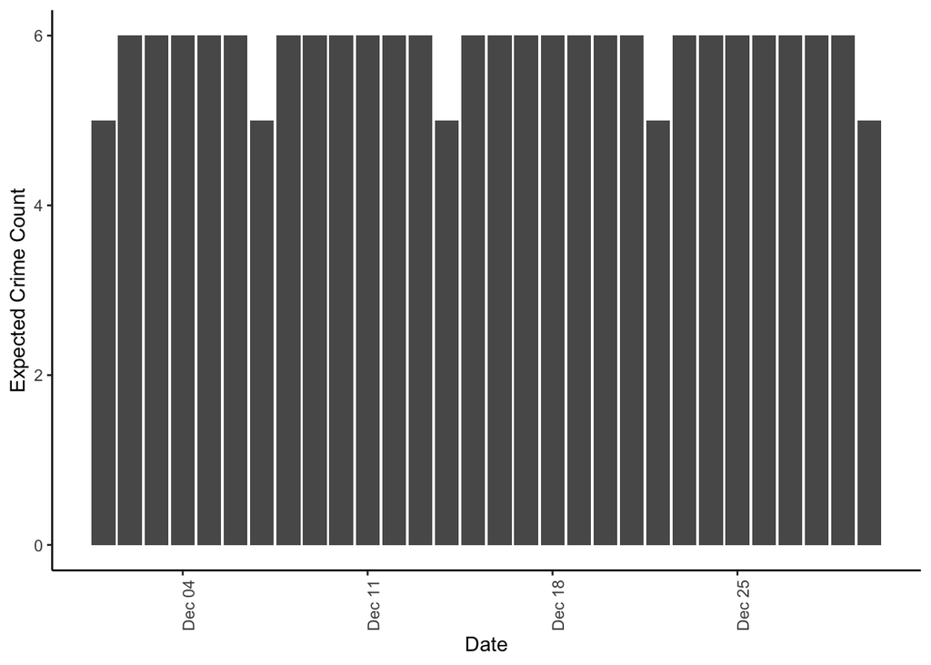

#### Temporal topology for all prior Decembers, by day and hour

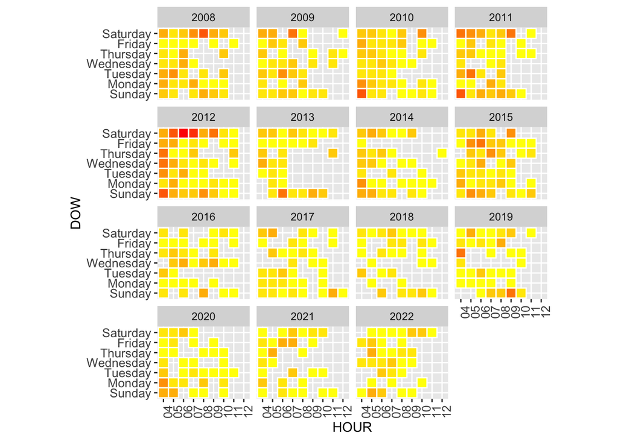

#### Hotspot map for all prior Decembers

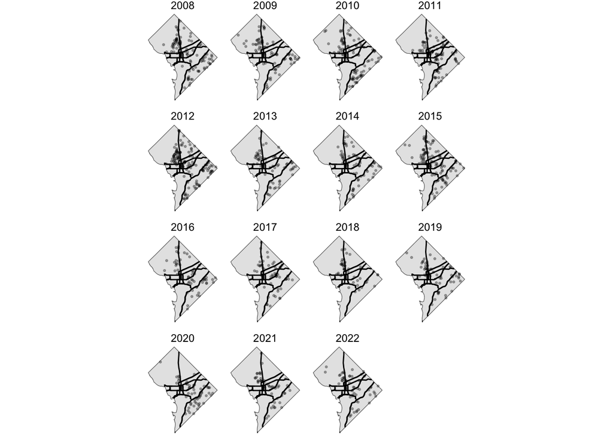

#### Analysis

The daily forecast for expected robberies during midnight shifts in December is relatively consistent. There is a pattern in which there is 1 day with 5 expected robberies, followed by an increase to 6 expected robberies for 5 to 7 days. Activity has occurred on all days of the week since 2008, with the most activity occuring on Saturdays and Sundays. Activity is documented from 4am to 12pm, but occurs less often from 11am to 12pm and most often from 4am to 6am. There is a significant decrease in activity over time, in which there used to be high levels of activity during the majority of hours stated above every day from 2008 to 2012, but since 2013 there were decreasingly low levels of activity during fewer hours every day. There were hot spots in the center of DC and southeast DC from 2008 to 2012, and from 2013 to 2022 they were still visible but less prominent due to the decrease in activity. Additionally, there were consistent cold spots with almost no activity from 2008 to 2022 in northwest DC and southwest DC and a decrease in activity in northeast DC from 2008 to 2022.

## Overall Analysis of Forecasts

All three forecasts expect a similar and consistent amount of crimes per day in December, within a range of 4 to 6 crimes. There are 5 to 6 expected motor vehicle thefts per day during day shifts in December, representing the recent increase in thefts since 2022 that primarily occur in the eastern half of DC. There are 5 expected burglaries per day during evening shifts in December, representing the significant decrease in burglaries since 2016 that are scattered across DC. There are 5 to 6 expected robberies per day during midnight shifts in December, representing the decrease in robberies since 2013 and hot spots in southeast and central DC. These consistent number of crimes are expected everyday because the temporal topologies for each of the three crimes show that the respective crime has occurred all seven days of the week in Decembers from 2008 to 2022.